JUNGHYUN YANG

# Geospatial_01_exercise

Jun 4, 2022 • 2 min read

```python
import geopandas as gpd

from learntools.core import binder
binder.bind(globals())
from learntools.geospatial.ex1 import *
```

### 1) 데이터를 가져옵니다.

다음 셀을 사용하여 'loans_filepath'에 있는 쉐이프 파일을 로드하여 GeoDataFrame 'world_loans'를 만듭니다.

```python
loans_filepath = "data/kiva_loans/kiva_loans/kiva_loans.shp"

# Your code here: Load the data
world_loans = gpd.read_file(loans_filepath)

# Check your answer
world_loans.head()
# Uncomment to view the first five rows of the data
#world_loans.head()
q_1.check()
```

Correct

### 2) 데이터를 표시합니다.

변경 사항 없이 다음 코드 셀을 실행하여 국가 경계를 포함하는 GeoDataFrame "world"를 로드합니다.

```python
world_filepath = gpd.datasets.get_path('naturalearth_lowres')
world = gpd.read_file(world_filepath)
world.head()
```

|  | pop_est | continent | name | iso_a3 | gdp_md_est | geometry |
| --- | --- | --- | --- | --- | --- | --- |
| 0 | 920938 | Oceania | Fiji | FJI | 8374.0 | MULTIPOLYGON (((180.00000 -16.06713, 180.00000... |
| 1 | 53950935 | Africa | Tanzania | TZA | 150600.0 | POLYGON ((33.90371 -0.95000, 34.07262 -1.05982... |
| 2 | 603253 | Africa | W. Sahara | ESH | 906.5 | POLYGON ((-8.66559 27.65643, -8.66512 27.58948... |
| 3 | 35623680 | North America | Canada | CAN | 1674000.0 | MULTIPOLYGON (((-122.84000 49.00000, -122.9742... |
| 4 | 326625791 | North America | United States of America | USA | 18560000.0 | MULTIPOLYGON (((-122.84000 49.00000, -120.0000... |

"world" 및 "world_loans" GeoDataFrames를 사용하여 전 세계 Kiva 대출 위치를 시각화합니다.

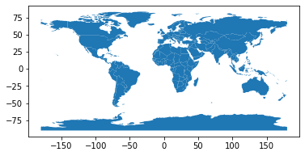

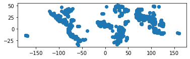

```python
world.plot()
world_loans.plot()
```

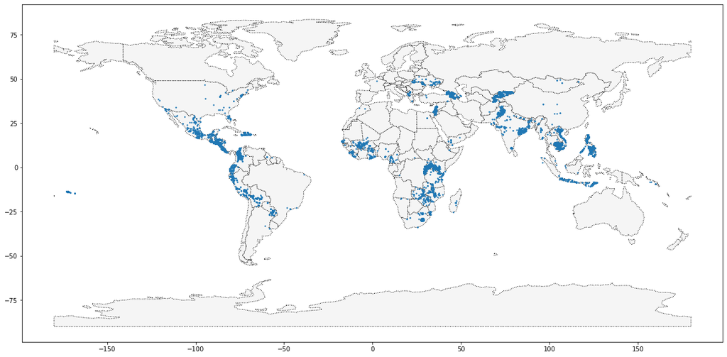

```python
ax = world.plot(figsize=(20,20), color='whitesmoke', linestyle=':', edgecolor='black')
world_loans.plot(ax=ax, markersize=2)
```

### 3) 필리핀을 기반으로 loans를 선택합니다.

다음으로, 당신은 필리핀에 기반을 둔 loans에 초점을 맞출 것이다. 다음 코드 셀을 사용하여 필리핀에 기반을 둔 loans이 있는 "world_loans"의 모든 행을 포함하는 GeoDataFrame "PHL_loans"를 만듭니다.

```python
PHL_loans = world_loans[world_loans['country'] == "Philippines"].copy()

# Check your answer
q_3.check()
```

Correct

```python
# PHL_loans = world_loans.loc[world_loans.country=="Philippines"].copy()
```

### 4) 필리핀의 loans를 이해합니다.

변경 없이 다음 코드 셀을 실행하여 필리핀의 모든 섬에 대한 경계를 포함하는 GeoDataFrame "PHL"을 로드합니다.

```python
gpd.io.file.fiona.drvsupport.supported_drivers['KML'] = 'rw'
PHL = gpd.read_file("data/Philippines_AL258.kml", driver='KML')
PHL.head()
```

|  | Name | Description | geometry |
| --- | --- | --- | --- |
| 0 | Autonomous Region in Muslim Mindanao |  | MULTIPOLYGON (((119.46690 4.58718, 119.46653 4... |
| 1 | Bicol Region |  | MULTIPOLYGON (((124.04577 11.57862, 124.04594 ... |
| 2 | Cagayan Valley |  | MULTIPOLYGON (((122.51581 17.04436, 122.51568 ... |
| 3 | Calabarzon |  | MULTIPOLYGON (((120.49202 14.05403, 120.49201 ... |
| 4 | Caraga |  | MULTIPOLYGON (((126.45401 8.24400, 126.45407 8... |

필리핀의 loans를 시각화하려면 'PHL'과 'PHL_loans' GeoDataFrame을 사용하십시오.

Hint: Use the `plot()` method of each GeoDataFrame.

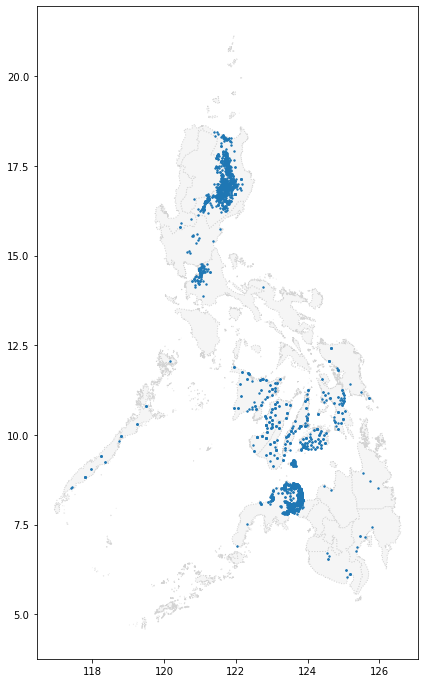

```python
ax = PHL.plot(figsize=(12,12), color='whitesmoke', linestyle=':', edgecolor='lightgray')
PHL_loans.plot(ax=ax, markersize=2)

# Uncomment to see a hint
#_COMMENT_IF(PROD)_
q_4.a.hint()
```

```python
# ax = PHL.plot(figsize=(12,12), color='whitesmoke', linestyle=':', edgecolor='lightgray')
# PHL_loans.plot(ax=ax, markersize=2)
```

```python
q_4.a.check()

# Uncomment to see our solution (your code may look different!)
#_COMMENT_IF(PROD)_
q_4.a.solution()
```

Thank you for creating a map!

Solution:

```
ax = PHL.plot(figsize=(12,12), color='whitesmoke', linestyle=':', edgecolor='lightgray')
PHL_loans.plot(ax=ax, markersize=2)
```

새로운 Field Partner를 모집하는 데 유용한 섬이 있습니까? 현재 키바의 손이 닿지 않는 곳에 있는 섬이 있나요?

질문에 답하는 데 [이 지도](https://bit.ly/2U2G7x7)가 유용할 수 있습니다.

```python
q_4.b.solution()
```

Solution: There are a number of potential islands, but **Mindoro** (in the central part of the Philippines) stands out as a relatively large island without any loans in the current dataset. This island is potentially a good location for recruiting new Field Partners!

# Keep going

Continue to learn about **coordinate reference systems**.